# Project Python Foundations: FoodHub Data Analysis For Durosinmi Elias

**Marks: 60**

### Context

The number of restaurants in New York is increasing day by day. Lots of students and busy professionals rely on those restaurants due to their hectic lifestyles. Online food delivery service is a great option for them. It provides them with good food from their favorite restaurants. A food aggregator company FoodHub offers access to multiple restaurants through a single smartphone app.

The app allows the restaurants to receive a direct online order from a customer. The app assigns a delivery person from the company to pick up the order after it is confirmed by the restaurant. The delivery person then uses the map to reach the restaurant and waits for the food package. Once the food package is handed over to the delivery person, he/she confirms the pick-up in the app and travels to the customer's location to deliver the food. The delivery person confirms the drop-off in the app after delivering the food package to the customer. The customer can rate the order in the app. The food aggregator earns money by collecting a fixed margin of the delivery order from the restaurants.

### Objective

The food aggregator company has stored the data of the different orders made by the registered customers in their online portal. They want to analyze the data to get a fair idea about the demand of different restaurants which will help them in enhancing their customer experience. Suppose you are hired as a Data Scientist in this company and the Data Science team has shared some of the key questions that need to be answered. Perform the data analysis to find answers to these questions that will help the company to improve the business.

### Data Description

The data contains the different data related to a food order. The detailed data dictionary is given below.

### Data Dictionary

- order_id: Unique ID of the order
- customer_id: ID of the customer who ordered the food
- restaurant_name: Name of the restaurant
- cuisine_type: Cuisine ordered by the customer
- cost: Cost of the order
- day_of_the_week: Indicates whether the order is placed on a weekday or weekend (The weekday is from Monday to Friday and the weekend is Saturday and Sunday)
- rating: Rating given by the customer out of 5
- food_preparation_time: Time (in minutes) taken by the restaurant to prepare the food. This is calculated by taking the difference between the timestamps of the restaurant's order confirmation and the delivery person's pick-up confirmation.
- delivery_time: Time (in minutes) taken by the delivery person to deliver the food package. This is calculated by taking the difference between the timestamps of the delivery person's pick-up confirmation and drop-off information

### Let us start by importing the required libraries

```python
# import libraries for data manipulation
import numpy as np
import pandas as pd

# import libraries for data visualization
import matplotlib.pyplot as plt
import seaborn as sns
sns.set()
```

### Understanding the structure of the data

```python
# read the data
df = pd.read_csv('foodhub_order.csv')
# returns the first 5 rows
df.head()
```

|  | order_id | customer_id | restaurant_name | cuisine_type | cost_of_the_order | day_of_the_week | rating | food_preparation_time | delivery_time |
| --- | --- | --- | --- | --- | --- | --- | --- | --- | --- |
| 0 | 1477147 | 337525 | Hangawi | Korean | 30.75 | Weekend | Not given | 25 | 20 |
| 1 | 1477685 | 358141 | Blue Ribbon Sushi Izakaya | Japanese | 12.08 | Weekend | Not given | 25 | 23 |
| 2 | 1477070 | 66393 | Cafe Habana | Mexican | 12.23 | Weekday | 5 | 23 | 28 |
| 3 | 1477334 | 106968 | Blue Ribbon Fried Chicken | American | 29.20 | Weekend | 3 | 25 | 15 |
| 4 | 1478249 | 76942 | Dirty Bird to Go | American | 11.59 | Weekday | 4 | 25 | 24 |

#### Observations:

The DataFrame has 9 columns as mentioned in the Data Dictionary. Data in each row corresponds to the order placed by a customer.

### **Question 1:** How many rows and columns are present in the data? [0.5 mark]

```python
# Write your code here
# 1898 Rows and 9 Columns in total
df.shape
```

```
(1898, 9)
```

#### Observations: There are 1898 rows and 9 columns in the dataframe

### **Question 2:** What are the datatypes of the different columns in the dataset? (The info() function can be used) [0.5 mark]

```python
# Use info() to print a concise summary of the DataFrame
df.info()
```

```
<class 'pandas.core.frame.DataFrame'>
RangeIndex: 1898 entries, 0 to 1897
Data columns (total 9 columns):
 #   Column                 Non-Null Count  Dtype
---  ------                 --------------  -----
 0   order_id               1898 non-null   int64
 1   customer_id            1898 non-null   int64
 2   restaurant_name        1898 non-null   object
 3   cuisine_type           1898 non-null   object
 4   cost_of_the_order      1898 non-null   float64
 5   day_of_the_week        1898 non-null   object
 6   rating                 1898 non-null   object
 7   food_preparation_time  1898 non-null   int64
 8   delivery_time          1898 non-null   int64
dtypes: float64(1), int64(4), object(4)
memory usage: 133.6+ KB
```

#### Observations:

order_id is of datatype int64 (numbers)

customer_id - int64 (numbers)

restaurant_name - object (string)

cuisine_type - object(string)

cost_of_the_order - float64(decimal numbers)

day_of_the_week - object(string)

rating - object

food_preparation_time - int64

delivery_time - int64

### **Question 3:** 'restaurant_name', 'cuisine_type', 'day_of_the_week' are object type attributes. Convert them to 'category' type. Does this result in reduced memory usage? (Check the info() function) [1 mark]

```python
# Converting "objects" to "category" reduces the data space required to store the dataframe
# write the code to convert 'restaurant_name', 'cuisine_type', 'day_of_the_week' into categorical data

# Use info() to print a concise summary of the DataFrame
df.restaurant_name = df.restaurant_name.astype('category')
df.cuisine_type = df.cuisine_type.astype('category')
df.day_of_the_week = df.day_of_the_week.astype('category')
df.info()
```

```
<class 'pandas.core.frame.DataFrame'>
RangeIndex: 1898 entries, 0 to 1897
Data columns (total 9 columns):
 #   Column                 Non-Null Count  Dtype
---  ------                 --------------  -----
 0   order_id               1898 non-null   int64
 1   customer_id            1898 non-null   int64
 2   restaurant_name        1898 non-null   category
 3   cuisine_type           1898 non-null   category
 4   cost_of_the_order      1898 non-null   float64
 5   day_of_the_week        1898 non-null   category
 6   rating                 1898 non-null   object
 7   food_preparation_time  1898 non-null   int64
 8   delivery_time          1898 non-null   int64
dtypes: category(3), float64(1), int64(4), object(1)
memory usage: 102.7+ KB
```

#### Observations:

### **Question 4:** Check the statistical summary of the data. What is the minimum, average, and maximum time it takes for food to be prepared once an order is placed? [2 marks]

```python
# Write your code here
df.describe()
```

|  | order_id | customer_id | cost_of_the_order | food_preparation_time | delivery_time |
| --- | --- | --- | --- | --- | --- |
| count | 1.898000e+03 | 1898.000000 | 1898.000000 | 1898.000000 | 1898.000000 |
| mean | 1.477496e+06 | 171168.478398 | 16.498851 | 27.371970 | 24.161749 |
| std | 5.480497e+02 | 113698.139743 | 7.483812 | 4.632481 | 4.972637 |
| min | 1.476547e+06 | 1311.000000 | 4.470000 | 20.000000 | 15.000000 |
| 25% | 1.477021e+06 | 77787.750000 | 12.080000 | 23.000000 | 20.000000 |
| 50% | 1.477496e+06 | 128600.000000 | 14.140000 | 27.000000 | 25.000000 |
| 75% | 1.477970e+06 | 270525.000000 | 22.297500 | 31.000000 | 28.000000 |
| max | 1.478444e+06 | 405334.000000 | 35.410000 | 35.000000 | 33.000000 |

#### Observations:

### **Question 5:** How many orders are not rated? [1 mark]

```python
df.rating.value_counts()
```

```
Not given    736
5            588
4            386
3            188
Name: rating, dtype: int64
```

#### Observations:

736 orders are not rated

### Exploratory Data Analysis (EDA)

### **Question 6:** Explore all the variables and provide observations on their distributions. (Generally, histograms, boxplots, countplots, etc. are used for univariate exploration.) [9 marks]

```python
#function to create a boxplot with histogram along same scale

def histogram_boxplot(data, feature, figsize=(12, 7), kde=False, bins=None):

    f2, (ax_box2, ax_hist2) = plt.subplots(
        nrows=2,  # Number of rows of the subplot grid= 2
        sharex=True,  # x-axis will be shared among all subplots
        gridspec_kw={"height_ratios": (0.25, 0.75)},
        figsize=figsize,
    )  # creating the 2 subplots
    sns.boxplot(
        data=data, x=feature, ax=ax_box2, showmeans=True, color="green"
    )  # boxplot will be created and a star will indicate the mean value of the column
    sns.histplot(
        data=data, x=feature, kde=kde, ax=ax_hist2, bins=bins, palette="winter"
    ) if bins else sns.histplot(
        data=data, x=feature, kde=kde, ax=ax_hist2
    )  # For histogram
    ax_hist2.axvline(
        data[feature].mean(), color="green", linestyle="--"
    )  # Add mean to the histogram
    ax_hist2.axvline(
        data[feature].median(), color="black", linestyle="-"
    )  # Add median to the histogram
```

```python
def labeled_barplot(data, feature, perc=False, n=None):


    total = len(data[feature])  # length of the column
    count = data[feature].nunique()
    if n is None:
        plt.figure(figsize=(count + 1, 5))
    else:
        plt.figure(figsize=(n + 1, 5))

    plt.xticks(rotation=90, fontsize=15)
    ax = sns.countplot(
        data=data,
        x=feature,
        palette="Paired",
        order=data[feature].value_counts().index[:n].sort_values(),
    )

    for p in ax.patches:
        if perc == True:
            label = "{:.1f}%".format(
                100 * p.get_height() / total
            )  # percentage of each class of the category
        else:
            label = p.get_height()  # count of each level of the category

        x = p.get_x() + p.get_width() / 2  # width of the plot
        y = p.get_height()  # height of the plot

        ax.annotate(
            label,
            (x, y),
            ha="center",
            va="center",
            size=12,
            xytext=(0, 5),
            textcoords="offset points",
        )  # annotate the percentage

    plt.show()  # show the plot
```

Cost of the order

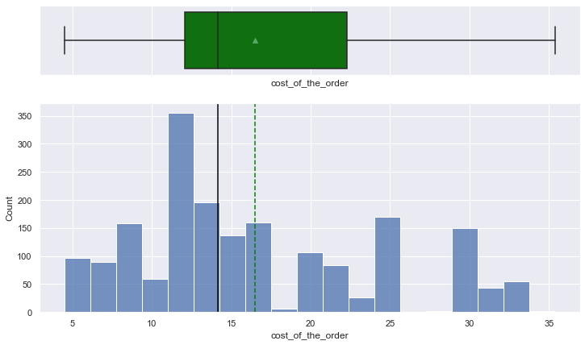

```python
histogram_boxplot(df, 'cost_of_the_order')
```

Rating

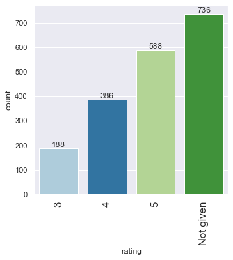

```python
labeled_barplot(df, 'rating')
```

Food Preparation time

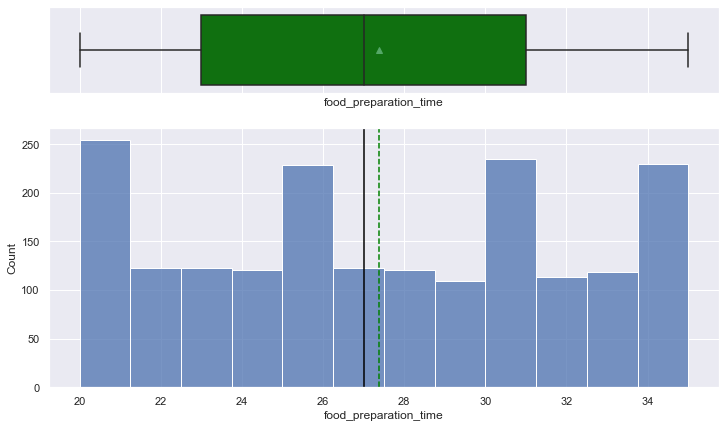

```python
histogram_boxplot(df, 'food_preparation_time')
```

Delivery time

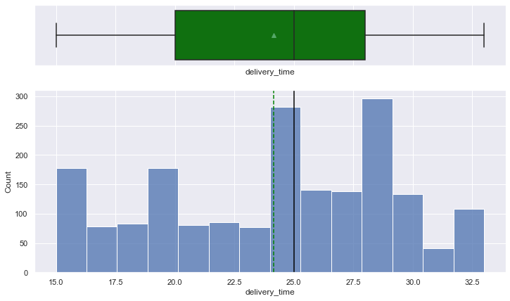

```python
histogram_boxplot(df, 'delivery_time')
```

Number of Cuisine order

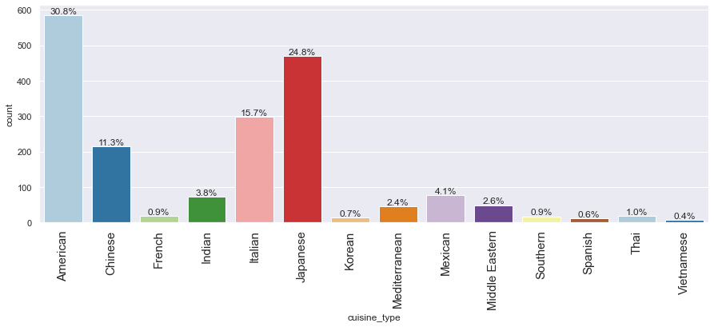

```python
labeled_barplot(df, "cuisine_type", perc=True)
```

**Check Order ID**

```python
# check unique order ID
df["order_id"].value_counts()
```

```
1477147    1
1477697    1
1477555    1
1478028    1
1478308    1
          ..
1478087    1
1476775    1
1478421    1
1476774    1
1478056    1
Name: order_id, Length: 1898, dtype: int64
```

**There are 1898 Unique orders**

**Unique Customers**

```python
# check unique customer ID
len(set(df["customer_id"]))
```

```
1200
```

**There are 1200 Unique Customers**

```python
df["customer_id"].value_counts().head()
```

```
52832     13
47440     10
83287      9
250494     8
259341     7
Name: customer_id, dtype: int64
```

Customer with ID 52832 ordered more . Ordered a total of 13

```python
# check the unique values
df["day_of_the_week"].value_counts()
```

```
Weekend    1351
Weekday     547
Name: day_of_the_week, dtype: int64
```

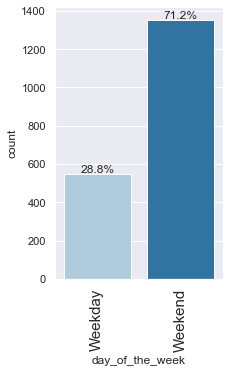

```python
labeled_barplot(df, "day_of_the_week", perc=True)
```

Observations: More orders came from the weekend.

### **Question 7**: Which are the top 5 restaurants in terms of the number of orders received? [1 mark]

```python
# Write the code here
df['restaurant_name'].value_counts()[:5]
```

```
Shake Shack                  219
The Meatball Shop            132
Blue Ribbon Sushi            119
Blue Ribbon Fried Chicken     96
Parm                          68
Name: restaurant_name, dtype: int64
```

#### Observations:

The top restuarant are

Shake Shack 219 The Meatball Shop 132 Blue Ribbon Sushi 119 Blue Ribbon Fried Chicken 96 Parm 68

### **Question 8**: Which is the most popular cuisine on weekends? [1 mark]

```python
# Write the code here
df_weekend = df[df['day_of_the_week'] == 'Weekend']
df_weekend['cuisine_type'].value_counts()
```

```
American          415
Japanese          335
Italian           207
Chinese           163
Mexican            53
Indian             49
Mediterranean      32
Middle Eastern     32
Thai               15
French             13
Korean             11
Southern           11
Spanish            11
Vietnamese          4
Name: cuisine_type, dtype: int64
```

#### Observations:

American cuisine is the most popular .since it is the most ordered.It can be seen from the analysis that 415 orders where made .

### **Question 9**: What percentage of the orders cost more than 20 dollars? [2 marks]

```python
# Write the code here
#first get order that cost above 20usd by filtering
df_greater_than_20 = df[df['cost_of_the_order']>20]
#print the appropriate column name to get orders having cost above $20 and calculate the number of total orders where the cost is above 20 usd
print('The number of total orders that cost above 20 dollars is:',
      df_greater_than_20.shape[0])

#now to get the percentage of such orders
percentage_orders = (df_greater_than_20.shape[0] /df.shape[0]) *100

print("Percentage of orders above 20 dollars:", round(percentage_orders,2),'%')
```

```
The number of total orders that cost above 20 dollars is: 555
Percentage of orders above 20 dollars: 29.24 %
```

#### Observations:

### **Question 10**: What is the mean order delivery time? [1 mark]

```python
# Write the code here
# Get the mean delivery time
mean_del_time = df['delivery_time'].mean()

print('The mean delivery time for this dataset is',
      round(mean_del_time, 2), 'minutes')
```

```
The mean delivery time for this dataset is 24.16 minutes
```

#### Observations:

### **Question 11:** The company has decided to give 20% discount vouchers to the top 5 most frequent customers. Find the IDs of these customers and the number of orders they placed. [1 mark]

```python
# Get the counts of  each customer_id
df['customer_id'].value_counts().head()
```

```
52832     13
47440     10
83287      9
250494     8
259341     7
Name: customer_id, dtype: int64
```

#### Observations:

### **Question 12**: Perform a multivariate analysis to explore relationships between the important variables in the dataset. (It is a good idea to explore relations between numerical variables as well as relations between numerical and categorical variables) [10 marks]

**Cuisine vs cost of order**

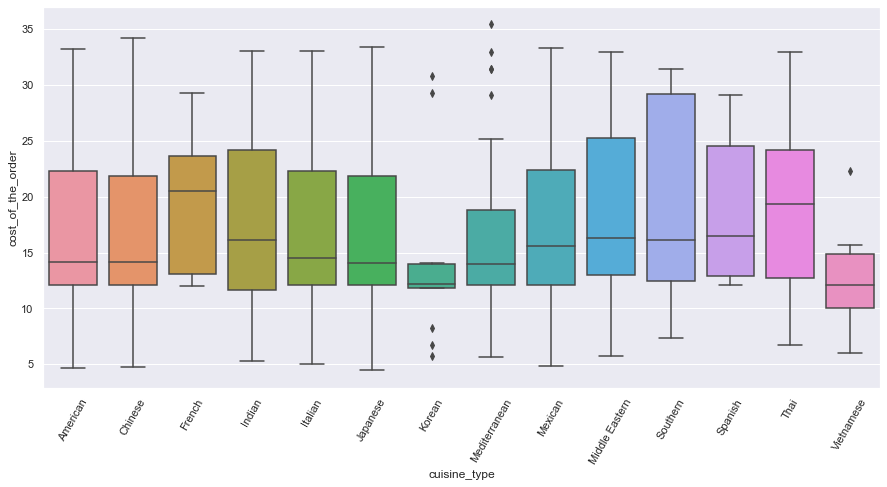

```python
# Relationship between cost of the order and cuisine type
plt.figure(figsize=(15, 7))
sns.boxplot(x="cuisine_type", y="cost_of_the_order", data=df)
plt.xticks(rotation=60)
plt.show()
```

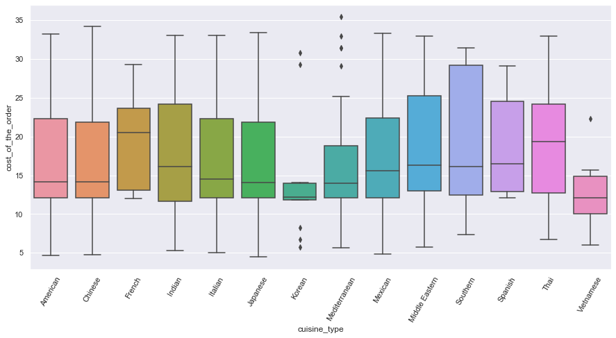

```python
# Relationship between food preparation time and cuisine type
plt.figure(figsize=(15, 7))
sns.boxplot(x="cuisine_type", y="cost_of_the_order", data=df)
plt.xticks(rotation=60)
plt.show()
```

**Restaurant and the revenues generated by each of them**

```python
df.groupby(['restaurant_name'])['cost_of_the_order'].sum(
).sort_values(ascending=False).head(14)
```

```
restaurant_name
Shake Shack                      3579.53
The Meatball Shop                2145.21
Blue Ribbon Sushi                1903.95
Blue Ribbon Fried Chicken        1662.29
Parm                             1112.76
RedFarm Broadway                  965.13
RedFarm Hudson                    921.21
TAO                               834.50
Han Dynasty                       755.29
Blue Ribbon Sushi Bar & Grill     666.62
Rubirosa                          660.45
Sushi of Gari 46                  640.87
Nobu Next Door                    623.67
Five Guys Burgers and Fries       506.47
Name: cost_of_the_order, dtype: float64
```

**Rating vs Delivery Time**

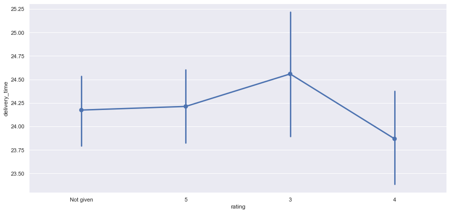

```python
# Relationship between rating and delivery time
plt.figure(figsize=(15, 7))
sns.pointplot(x='rating', y='delivery_time', data=df)
plt.show()
```

**Rating and Food preparation time**

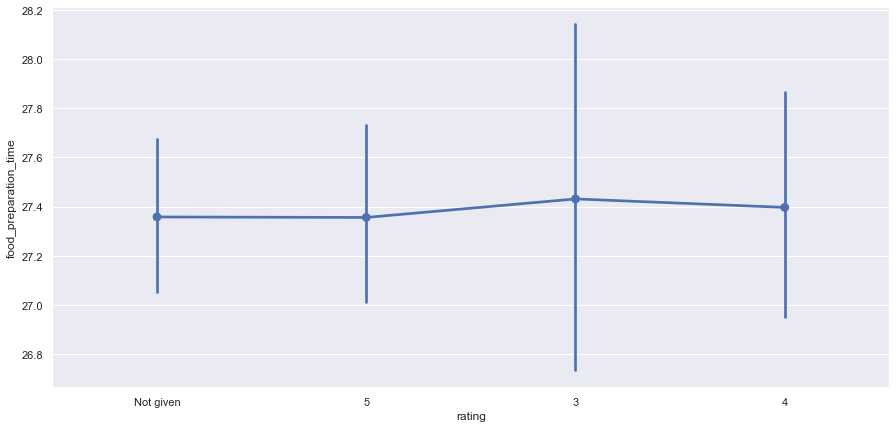

```python
# Relationship between rating and food preparation time
plt.figure(figsize=(15, 7))
sns.pointplot(x="rating", y="food_preparation_time", data=df)
plt.show()
```

**Rating and cost of the order**

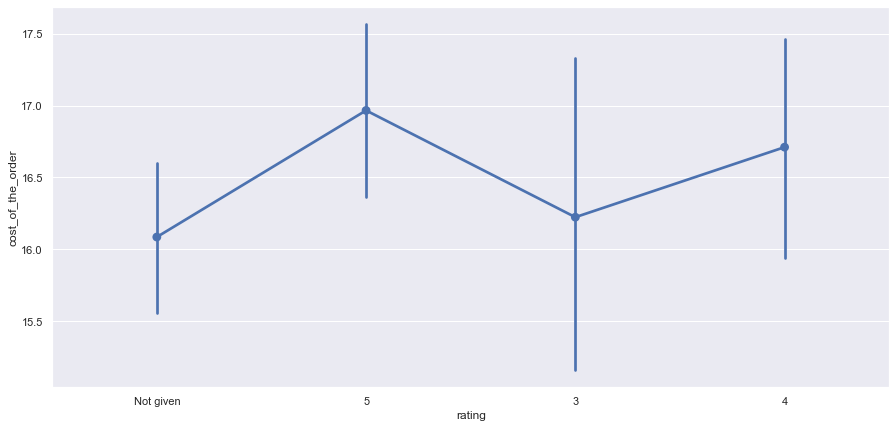

```python
# Relationship between rating and cost of the order
plt.figure(figsize=(15, 7))
sns.pointplot(x='rating', y='cost_of_the_order', data=df)
plt.show()
```

### **Question 13:** The company wants to provide a promotional offer in the advertisement of the restaurants. The condition to get the offer is that the restaurants must have a rating count of more than 50 and the average rating should be greater than 4. Find the restaurants fulfilling the criteria to get the promotional offer. [3 marks]

```python
# Write the code here
# Filter the rated restaurants
df_rated = df[df['rating'] != 'Not given'].copy()

# Convert rating column from object to integer allows for certain arithmetic calculation to be done
df_rated['rating'] = df_rated['rating'].astype('int')

# Create a dataframe that contains the restaurant names with their rating counts
df_rating_count = df_rated.groupby(['restaurant_name'])[
    'rating'].count().sort_values(ascending=False).reset_index()
df_rating_count.head()
```

|  | restaurant_name | rating |
| --- | --- | --- |
| 0 | Shake Shack | 133 |
| 1 | The Meatball Shop | 84 |
| 2 | Blue Ribbon Sushi | 73 |
| 3 | Blue Ribbon Fried Chicken | 64 |
| 4 | RedFarm Broadway | 41 |

```python
# Get the restaurant names that have rating count more than 50
rest_names = df_rating_count[df_rating_count['rating'] > 50]['restaurant_name']
rest_names
# Filter to get the data of restaurants that have rating count more than 50
df_mean_4 = df_rated[df_rated['restaurant_name'].isin(rest_names)].copy()

# Group the restaurant names with their ratings and find the mean rating of each restaurant
df_mean_4.groupby(['restaurant_name'])['rating'].mean(
).sort_values(ascending=False).reset_index().dropna()
```

|  | restaurant_name | rating |
| --- | --- | --- |
| 0 | The Meatball Shop | 4.511905 |
| 1 | Blue Ribbon Fried Chicken | 4.328125 |
| 2 | Shake Shack | 4.278195 |
| 3 | Blue Ribbon Sushi | 4.219178 |

#### Observations:

### **Question 14:** The company charges the restaurant 25% on the orders having cost greater than 20 dollars and 15% on the orders having cost greater than 5 dollars. Find the net revenue generated by the company across all orders. [3 marks]

```python
# Write the code here
#function to determine the revenue
def compute_rev(x):
    if x > 20:
        return x*0.25
    elif x > 5:
        return x*0.15
    else:
        return x*0


# Write the appropriate column name to compute the revenue
df['Revenue'] = df['cost_of_the_order'].apply(compute_rev)
df.head()
```

|  | order_id | customer_id | restaurant_name | cuisine_type | cost_of_the_order | day_of_the_week | rating | food_preparation_time | delivery_time | Revenue |
| --- | --- | --- | --- | --- | --- | --- | --- | --- | --- | --- |
| 0 | 1477147 | 337525 | Hangawi | Korean | 30.75 | Weekend | Not given | 25 | 20 | 7.6875 |
| 1 | 1477685 | 358141 | Blue Ribbon Sushi Izakaya | Japanese | 12.08 | Weekend | Not given | 25 | 23 | 1.8120 |
| 2 | 1477070 | 66393 | Cafe Habana | Mexican | 12.23 | Weekday | 5 | 23 | 28 | 1.8345 |
| 3 | 1477334 | 106968 | Blue Ribbon Fried Chicken | American | 29.20 | Weekend | 3 | 25 | 15 | 7.3000 |
| 4 | 1478249 | 76942 | Dirty Bird to Go | American | 11.59 | Weekday | 4 | 25 | 24 | 1.7385 |

```python
# get the total revenue and print it
total_rev = df['Revenue'].sum()
print('The net revenue is around', round(total_rev, 2), 'dollars')
```

```
The net revenue is around 6166.3 dollars
```

#### Observations:

### **Question 15:** The company wants to analyze the total time required to deliver the food. What percentage of orders take more than 60 minutes to get delivered from the time the order is placed? (The food has to be prepared and then delivered.) [2 marks]

```python
# Write the code here
# add a new column to the dataframe df to store the total delivery time
df["total_time"] = df["food_preparation_time"] + df["delivery_time"]

# find the percentage of orders that have more than 60 minutes of total delivery time
print(
    "The percentage of orders that have more than 60 minutes of total delivery time is",
    round(df[df["total_time"] > 60].shape[0] / df.shape[0] * 100, 2),
    "%",
)
```

```
The percentage of orders that have more than 60 minutes of total delivery time is 10.54 %
```

#### Observations:

- Approximately 10.54 % of the total orders have more than 60 minutes of total delivery time.

### **Question 16:** The company wants to analyze the delivery time of the orders on weekdays and weekends. How does the mean delivery time vary during weekdays and weekends? [2 marks]

```python
# Write the code here
# get the mean delivery time on weekdays and print it

weekday_avg_time = round(
    df.loc[df["day_of_the_week"] == "Weekday", "delivery_time"].mean()
)

print(f"The mean delivery time on weekdays is around {weekday_avg_time} minutes",)

# get the mean delivery time on weekends and print it
print(
    "The mean delivery time on weekends is around",
    round(df[df["day_of_the_week"] == "Weekend"]["delivery_time"].mean()),
    "minutes",
)
```

```
The mean delivery time on weekdays is around 28 minutes
The mean delivery time on weekends is around 22 minutes
```

#### Observations:

### **Question 17:** What are your conclusions from the analysis? What recommendations would you like to share to help improve the business? (You can use cuisine type and feedback ratings to drive your business recommendations.) [6 marks]

### Conclusion and Recommendations

- a certain number of people have no ratings for orders which is around 39%.
- Order demands are usually higher on weekends.
- Shakeshack has the highest number of orders

**Recommendations:**

- Increase the staff on weekends as order rates are high and this will allow for delivery on time as well.
- Rating is a very important factor to determine customer satisfaction. I believe they could incentivize Rating. E.g when a customer rates an order they get bonus point that could be used much later for orders.